# R4DS_2E_spreadsheets

Martin

2026-01-19

## Spreadsheets - Excel

1. In an Excel file, create the following dataset and save it as survey.xlsx.(Its in the folder “data”) Then, read it into R, with survey_id as a character variable and n_pets as a numerical variable.

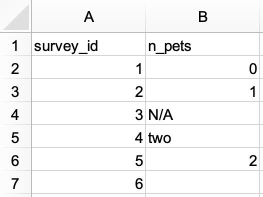

```r
survey <- read_excel(
  "data/survey.xlsx",
  col_types = c("text", "numeric")
  )
survey
```

```
## # A tibble: 6 × 2
##   survey_id n_pets
##   <chr>      <dbl>
## 1 1.0            0
## 2 2.0            1
## 3 3.0           NA
## 4 4.0           NA
## 5 5.0            2
## 6 6.0           NA
```

```r
# We can see some issues. When changing a number to text we get an unnecessary floating point "number" of 1.0, 2.0 etc. `n_pets` also mixes text with numbers and there is an N/A value followed by an empty cell which I imagine also should be considered a missing value. Lets fix a few things up.

survey <- read_excel(
  "data/survey.xlsx",
  na = c("", "N/A"),
  col_types = c("text", "text")
  )
survey
```

```
## # A tibble: 6 × 2
##   survey_id n_pets
##   <chr>     <chr>
## 1 1.0       0.0
## 2 2.0       1.0
## 3 3.0       <NA>
## 4 4.0       two
## 5 5.0       2.0
## 6 6.0       <NA>
```

```r
survey <- survey |>
  mutate(
    n_pets = if_else(n_pets == "two", "2", n_pets),
    n_pets = parse_number(n_pets),
    survey_id = str_replace(survey_id, "\\.0", "")
  )
survey
```

```
## # A tibble: 6 × 2
##   survey_id n_pets
##   <chr>      <dbl>
## 1 1              0
## 2 2              1
## 3 3             NA
## 4 4              2
## 5 5              2
## 6 6             NA
```

2. In another Excel file, create the following dataset and save it as roster.xlsx. (Again in the folder “data”)

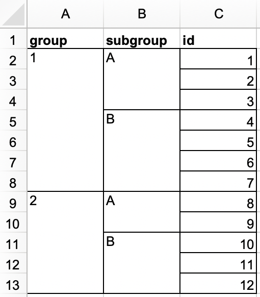

   Then, read it into R. The resulting data frame should be called roster and should look like the following.

```r
roster <- read_excel(
  "data/roster.xlsx",
  col_types = c("numeric", "text", "numeric")
  )
roster <- roster |>
  fill(c(group, subgroup), .direction = "down")
# This was seen in a previous chapter
```

3. In a new Excel file, create the following dataset and save it as sales.xlsx. (Its in “data” folder)

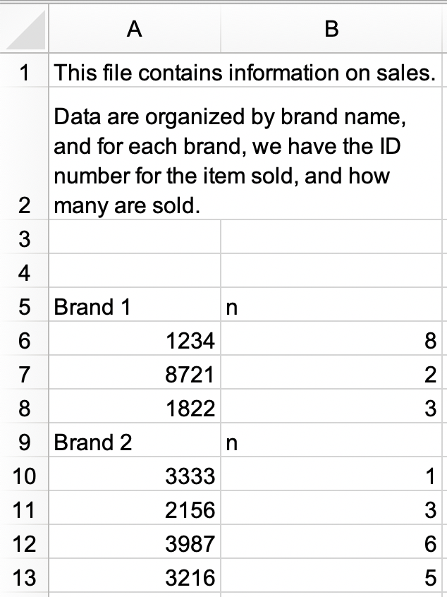

1. 1. Read sales.xlsx in and save as sales. The data frame should look like the following, with id and n as column names and with 9 rows.

```r
sales <- read_excel(
  "data/sales.xlsx",
  col_names = c("id", "n"),
  skip = 4,
  col_types = c("text", "text")
  )
sales
```

```
## # A tibble: 9 × 2
##   id      n
##   <chr>   <chr>
## 1 Brand 1 n
## 2 1234.0  8.0
## 3 8721.0  2.0
## 4 1822.0  3.0
## 5 Brand 2 n
## 6 3333.0  1.0
## 7 2156.0  3.0
## 8 3987.0  6.0
## 9 3216.0  5.0
```

2. Modify sales further to get it into the following tidy format with three columns (brand, id, and n) and 7 rows of data. Note that id and n are numeric, brand is a character variable.

```r
sales |>
  slice(-c(1, 5)) |>
  mutate(
    brand = rep(c("Brand 1", "Brand 2"), c(3, 4)),
    id = as.numeric(id),
    n = as.numeric(n)
    ) |>
  relocate(brand)
```

```
## # A tibble: 7 × 3
##   brand      id     n
##   <chr>   <dbl> <dbl>
## 1 Brand 1  1234     8
## 2 Brand 1  8721     2
## 3 Brand 1  1822     3
## 4 Brand 2  3333     1
## 5 Brand 2  2156     3
## 6 Brand 2  3987     6
## 7 Brand 2  3216     5
```

4. Recreate the bake_sale data frame, write it out to an Excel file using the write.xlsx() function from the openxlsx package.

```r
bake_sale <- tibble(
  item     = factor(c("brownie", "cupcake", "cookie")),
  quantity = c(10, 5, 8)
)

bake_sale
```

```
## # A tibble: 3 × 2
##   item    quantity
##   <fct>      <dbl>
## 1 brownie       10
## 2 cupcake        5
## 3 cookie         8
```

```r
write_xlsx(bake_sale, path = "data/bake-sale.xlsx")
```

5. In Chapter 7 you learned about the janitor::clean_names() function to turn column names into snake case. Read the students.xlsx file that we introduced earlier in this section and use this function to “clean” the column names.

```r
students <- read_excel("data/students.xlsx")

students <- students |>
  janitor::clean_names()

students
```

```
## # A tibble: 6 × 5
##   student_id full_name        favourite_food     meal_plan           age
##        <dbl> <chr>            <chr>              <chr>               <chr>
## 1          1 Sunil Huffmann   Strawberry yoghurt Lunch only          4.0
## 2          2 Barclay Lynn     French fries       Lunch only          5.0
## 3          3 Jayendra Lyne    N/A                Breakfast and lunch 7.0
## 4          4 Leon Rossini     Anchovies          Lunch only          <NA>
## 5          5 Chidiegwu Dunkel Pizza              Breakfast and lunch five
## 6          6 Güvenç Attila    Ice cream          Lunch only          6.0
```

6. What happens if you try to read in a file with .xlsx extension with read_xls()?

```r
students <- read_xls("data/students.xlsx")
```

```
## Error:
##   filepath: C:\Users\schoend\Desktop\r4ds_Lukic_Solutions_021025\r4ds-2e-exercise-solutions-main\data\students.xlsx
##   libxls error: Unable to open file
```

```r
# We get an error saying that read_xls was unable to open the file
```

## Spreadsheets - Google Sheets

Since these questions involve some sort of authentication via a google email, I’m going to pass on doing these questions for the time being.

1. Read the students dataset from earlier in the chapter from Excel and also from Google Sheets, with no additional arguments supplied to the read_excel() and read_sheet() functions. Are the resulting data frames in R exactly the same? If not, how are they different?

```r
students_excel <- read_xlsx("data/students.xlsx")
students_sheet_id <- "1V1nPp1tzOuutXFLb3G9Eyxi3qxeEhnOXUzL5_BcCQ0w"
students_google <- read_sheet(students_sheet_id)
```

```
## Error in `gs4_auth()`:
## ! Can't get Google credentials.
## ℹ Are you running googlesheets4 in a non-interactive session? Consider:
## • Call `gs4_deauth()` to prevent the attempt to get credentials.
## • Call `gs4_auth()` directly with all necessary specifics.
## ℹ See gargle's "Non-interactive auth" vignette for more details:
```